# Effects of Borrower Characteristics on The Interest Rate From Prosper

## Borrower Rate vs. Debt to Income Ratio by Credit Grade

After limiting the range of DebtToIncomeRatio to eliminate outliers, we can see that there is a roughly positive linear relationship between the borrower's interest rate and debt-to-income ratio for each credit grade, especially for AA, A, and B.

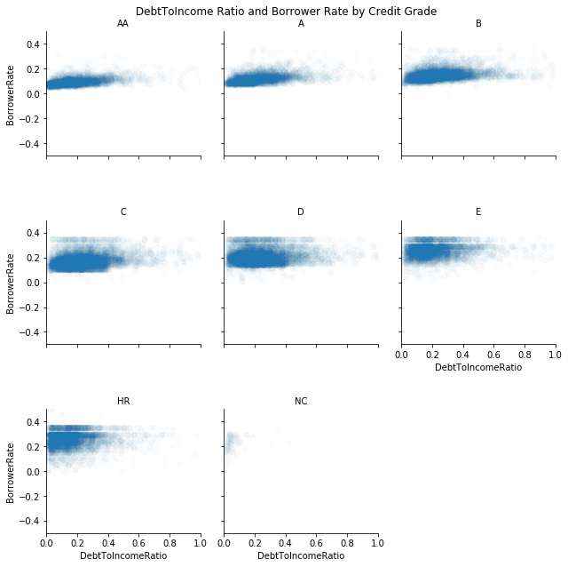

```python
# CreditGrade & DebtToIncomeRatio & BorrowerRate
p = sb.FacetGrid(data = df, col = "CreditGrade", col_wrap = 3)
p.map(plt.scatter,"DebtToIncomeRatio", "BorrowerRate", alpha = 0.02)
plt.xlim((0,1));
plt.ylim((-0.5,0.5));
p.fig.suptitle(" DebtToIncome Ratio and Borrower Rate by Credit Grade");
plt.subplots_adjust(top = 0.1);
p.set_titles("{col_name}");
p.fig.tight_layout();
```

## Borrower Rate and Average Credit score by IsBorrowerHomeowner

The none-homeowner have more records in upper left and lower credit score with higher borrower’s interest rate.

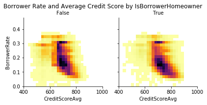

```python
# BorrowerRate & CreditScoreAvg & IsBorrowerHomeowner
p = sb.FacetGrid(data = df, col = "IsBorrowerHomeowner", col_wrap = 2)
p.map(hist2dplot,"CreditScoreAvg","BorrowerRate")
plt.xlim((400,1000))
p.fig.suptitle("Borrower Rate and Average Credit Score by IsBorrowerHomeowner");
plt.subplots_adjust(top = 0.3);
p.set_titles("{col_name}");
p.fig.tight_layout();
```

## Borrower Rate and Average Credit Score by Employment Status

```python
# BorrowerRate & CreditScoreAvg & EmploymentStatus
p = sb.FacetGrid(data = df, col = "EmploymentStatus", col_wrap = 3)
p.map(hist2dplot,"CreditScoreAvg","BorrowerRate")
plt.xlim((400,1000))

p.set_titles("{col_name}");
p.fig.suptitle("Borrower Rate and Average Credit Score by Employment Status");
plt.subplots_adjust(top = 0.1);
p.fig.tight_layout();
```

[output not shown]

## Borrower Rate and Average Credit Score by Year

The slope of the average credit score and the borrower rate became steeper as the year increased, which meant that the borrower’s interest rate was increasingly sensitive to changes in credit score.

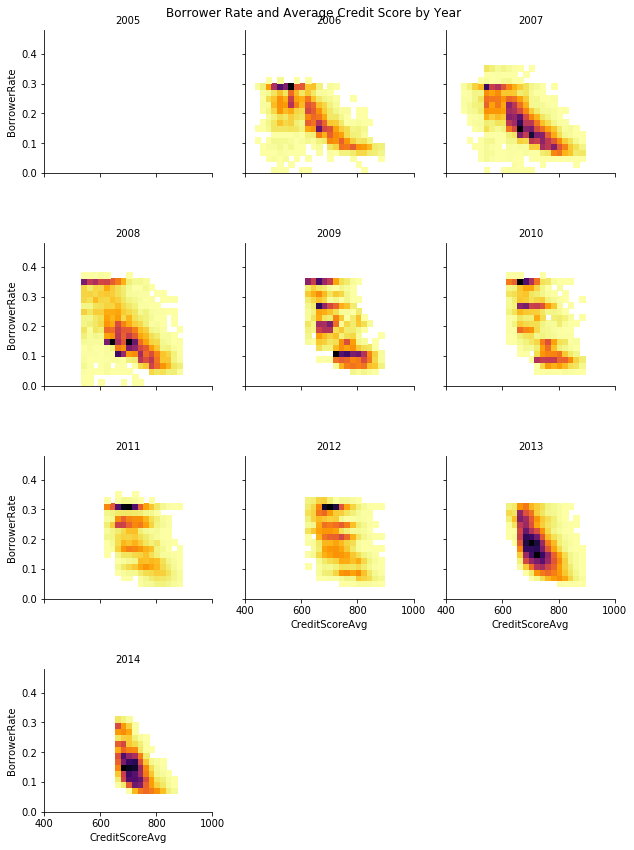

```python
# BorrowerRate & CreditScoreAvg & "year"
p = sb.FacetGrid(data = df, col = "year", col_wrap = 3)
p.map(hist2dplot,"CreditScoreAvg","BorrowerRate")
plt.xlim((400,1000))
p.set_titles("{col_name}");
p.fig.suptitle("Borrower Rate and Average Credit Score by Year");
plt.subplots_adjust(top = 0.1);
p.fig.tight_layout();
```

## Borrower rate and average credit score by term

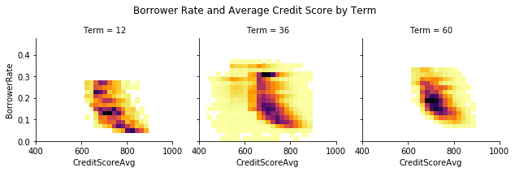

```python
p = sb.FacetGrid(data = df, col = "Term", col_wrap = 3)
p.map(hist2dplot,"CreditScoreAvg","BorrowerRate")
plt.xlim((400,1000))
p.fig.suptitle("Borrower Rate and Average Credit Score by Term");
plt.subplots_adjust(top=0.2);
p.fig.tight_layout();
```